# Mini-Project 2: Adventure 2

Jack Tan, Debbie Sun, Alex Denzler, Phuong Nguyen

```r
library(openxlsx)     #for data wrangling
library(dplyr)        #for data wrangling
library(caret)        #for model training
library(car)          #for model training
library(e1071)        #for model training, specific to SVM
library(kernlab)      #for model training, specific to SVM
library(ggplot2)      #for plotting
library(rminer)       #for model evaluation
library(pROC)         #for model evaluation
```

## Part 1: Background

### What is SVM?

Support Vector Machine is a non-parametric supervised machine learning algorithm that uses a hyperplane, a separation threshold in p dimensions, to make binary classifications. The optimal hyperplane is the one with the maximal margin where the smallest distance (margin) from the vectors (closest datapoints that influences the choice of optimal planes) are maximized. Because maximal margin hyperplane can be unduly sensitive to new data (potentially overfitting) that are vectors, Support Vector Classifier allows misclassifications to decrease this sensitivity and better perform on new datasets. The tuning of $\zeta$, or the positive slack variables, demonstrates a bias-variance trade-off in SVM. Support Vector Machines further extends this algorithm to cases of non-linear separations between categories by variable transformation.

### Hyperplane and Maximal Margin Hyperplane

In SVM, the hyperplane is a flat affine subspace of demension (p-1) in a p-dimension space that is used to classify the datapoints into categories correctly. There are many possible hyperplanes, and the optimal choice is the maximal margin hyperplane with the largest margin (margin is defined as the minimum of all distances from datapoints to the hyperplane). Using the maximal margin gives us a better split as each categories are as distinct from each other as possible, and a high accuracy for the model’s classifications.

### Support Vector Classifier and slack variable

In reality, a perfect split is not always possible when categories are not linearly separable or observations from different categories mix with each other. Support Vector Classifier adds the positive term slack variable $\zeta_i$ to allow for misclassifications, cases in which observations are on the wrong side of the margin or of the hyperplane, but also penalizes them. Each slack variable is determined by the distance between individual misclassified observations and the correct margin. Here, the optimal model minimizes $\zeta_i$ while maximizing the margin. The tolerance term is defined as $𝐶\Sigma\zeta_i$, where $\Sigma\zeta_i$ is the sum of distances from all misclassified observations to the correct margin and $𝐶$ is the regularization parameter that controls the trade-off between the slack variable penalty (misclassifications) and the width of the margin (similar to LASSO!).

### Tuning the regularization parameter C

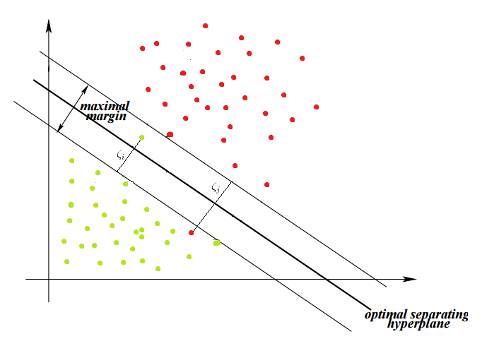

In SVM classification, the regularization parameter $𝐶$ tells the algorithm how much you care about misclassified points. To reiterate, SVM’s goal is to find the maximum-margin hyperplane, one that is as far from all datapoints or has as much room on both sides as possible. A high value for $𝐶$ means that we care more about classifying all training datapoints correctly than leaving wiggle room for future data. It tells the algorithm to punish misclassifications heavily, thus the algorithm will produce small margin with low tolerance (low variance, high bias). Conversely, low $𝐶$ values are used if we care more about leaving room for future data than classify all of the training points correctly. Then, misclassifications would be lightly punished and the algorithm will generate a larger margin with higher tolerance (high variance, low bias). When we increase $𝐶$, we are betting that our training dataset contains the most extreme cases and future data will be further from the boundary than the cases our training dataset contains, and vice versa. The best $𝐶$ is usually determined using CV.

### Support Vector Machine and kernel function

Support Vector Machine uses variable transformations to build non-linear hyperplanes. A kernel function is a variable transformation technique that takes two datapoints as inputs and returns a similarity score, which indicates how close datapoints. Thus, the closer the datapoints, the higher their simialrity scores. A cool thing about kernel functions is that in high dimensional spaces, where data could be hard to visualize and deal with, by using a kernel function, we can actually compute the similarity scores without doing any transformation on the data (i.e. reducing the dimension). Thus, a kernel trick is just using kernal function instead of using high-cost transformations.

Kernel functions commonly used for SVM are linear kernel function (default kernel function, visualization in image above), polynomial kernel function (the hyperplane takes polynomial degrees higher than 1), radial basis kernel function (probably one of the best and most practical kernel functions that works well when categories are not easily separable and when polynoimal kernel functions do not produce good classifications).

### Tuning parameter of a kernel function, $\gamma$

It’s hard to explain how this $\gamma$ parameter really works, but the idea is that when we use kernel functions to find the boundary suitable for our dataset, the boundary (called “Gaussian boundary”) dissipates as they get further from support vectors and this $\gamma$ parameter basically controls how quickly the dissipation happens. In general, if a large $\gamma$ is chosen, the boundary will dissipate more slowly, meaning that we have a more fixed boundary and, similar to using a large $𝐶$, we are betting that future data will fall within this more fixed boundary. These tunings correspond to a model with high bias and low variance. Vice versa, small $\gamma$ and small $𝐶$ results in low bias, high variance models.

### Pros and cons of SVM.

Pros:  
- The model given by SVM are guaranteed to be global instead of local optimum because SVM does not take a step-wise approach.  
- SVM is a spectacular method suitable for datasets with both linearly and non-linearly separable categories, the latter by using kernel tricks. The only thing to do is to tune the regularization parameter C.  
- SVM works well with datasets that have low dimentionality as well as data sets that have high dimensionality. The algorithm works well with high-dimension because the complexity of training data set in SVM is generally characterized by the support vectors rather than the dimension of the dataset.  
- SVM can work effectively on smaller training datasets because it does not rely on the entire data.

Cons:  
- SVM is really computationally expensive and thus should not be used with large datasets. - SVM is not so good at dealing with datasets that have multiple overlapping classes.

### Comparison between SVM and other classification algorithms

- SVM vs. Logistic Regression: Logistic regression is limited to binary classifications. Though SVM is by default only able to deal with binary predictors as well, as ISLR textbook mentions we can predict variables of more than 2 groups using techniques called one-versus-one classification or one-versus-all classification.
- SVM vs. KNN: In practice, KNN scales badly, produces blocky boundaries and models that are hard to interpret. Also, KNN does not work well with high dimensionality datasets. SVM in general does not have this problem and is better.
- SVM vs. Tree: Trees are greedy, giving the locally rather than globally optimal results. SVM is not greedy.
- SVM vs. RandomForest: An advantage of Randomforests is that it gives a probablistic model that indicates the probability that a given datapoint falls into a class. Aside from that, SVM usually gives better results in cases that it can perform well.

In general, SVM is better than other classification algorithms in cases when it can perform well. Considering the cons of SVM listed in the previous section, we generally do not want to use SVM when: 1) the given dataset has a lot of observations, say $10^6$, which makes it too computationally costly to use SVM, and 2) observations wrangle and cannot be separated. Although when data wrangles with each other all algorithms tend to perform badly, SVM usually does the worst in this case.

## Part 2: 2-predictor analysis

### Prepare the dataset

```r
#Load the dataset
kangaroo <- read.csv("https://www.macalester.edu/~ajohns24/data/kangaroo.csv")

#Set the seed
set.seed(253)

#Remove observations of the `melanops` species
kangaroo_selected <- kangaroo %>%
  filter(species != c("melanops")) %>%
  mutate_if(is.factor, ~droplevels(.))
levels(kangaroo_selected$species)
```

```
## [1] "fuliginosus" "giganteus"
```

```r
kangaroo_selected %>%
  count(kangaroo_selected$species)
```

```
## # A tibble: 2 x 2
##   `kangaroo_selected$species`     n
##   <fct>                       <int>
## 1 fuliginosus                    50
## 2 giganteus                      50
```

Here we dropped the `melanops` species for the sake of simplicity and because this species is not found in the region of interest. As we can see now, there are 50 observations of the `fuliginosus` species and 50 of the `giganteus` species. With this balance in observations between the two group, the predictions are unlikely to be biased towards either species.

### Visualization of `species` vs. 2 predictors

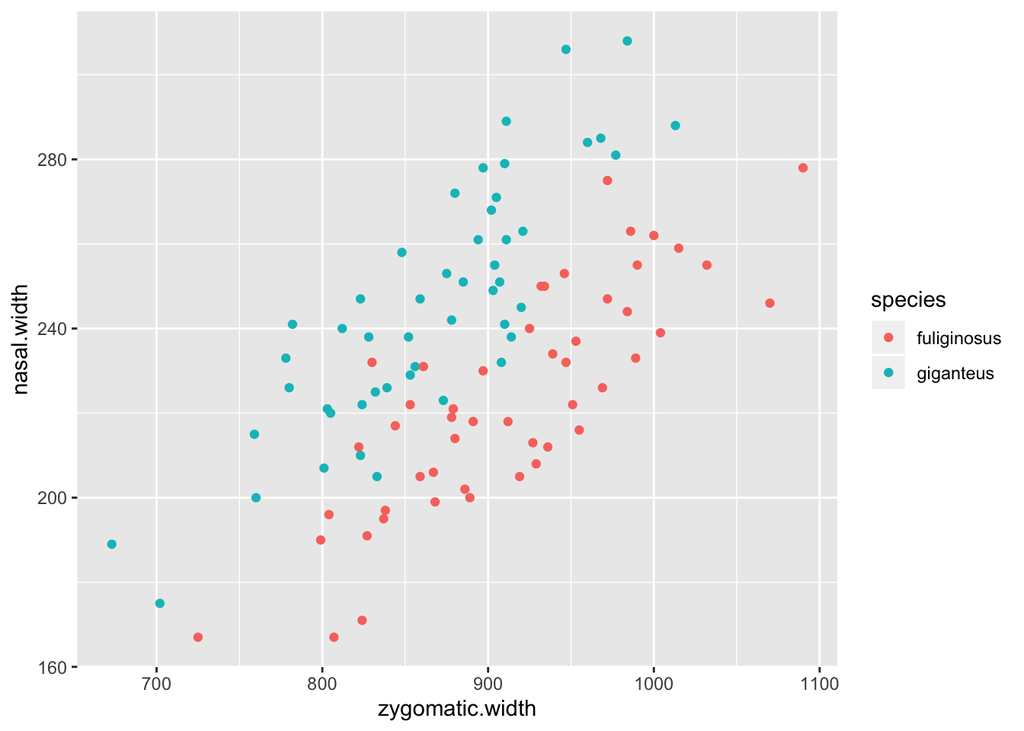

```r
ggplot(data = kangaroo_selected, aes(x = zygomatic.width, y = nasal.width, color = species)) +
  geom_point()
```

Since we are now only doing a two-dimension analysis on `zygomatic.width` and `nasal.width`, we can plot the dataset and see what kind of kernel we want to use for our SVM model. We can see that the two species are linearly separable in most cases and there are few cases that we want to penalize for misclassifications. Thus, a linear kernel seems sufficient and maybe we want a rather small value for the regularization parameter $𝐶$.

### Building 2-predictor Model

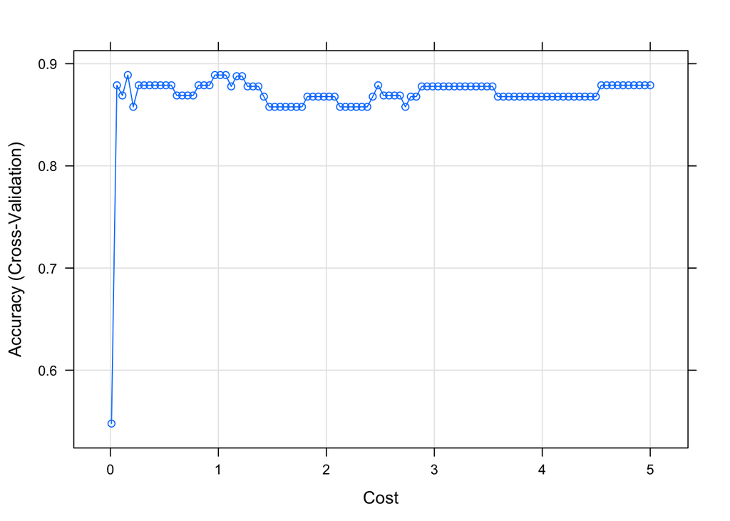

```r
#Set the seed
set.seed(253)

#Tuning parameters
c <- seq(0.01, 5, length = 100)
sig <- seq(0.01, 5, length = 100)

#Linear SVM model
svm_linear <- train(
  species ~ zygomatic.width + nasal.width,
  data = kangaroo_selected,
  method = "svmLinear",
  trControl=trainControl(method = "cv", number = 10, selectionFunction = "best"),
  preProcess = c("center", "scale"),
  metric = "Accuracy",
  tuneGrid = data.frame(C = c),
  na.action = na.omit
  )

#Plot the accuracies
plot(svm_linear)
```

```r
#Optimal model results
svm_linear$results %>%
  filter(C == svm_linear$bestTune$C)
```

```
##           C  Accuracy     Kappa AccuracySD   KappaSD
## 1 0.1612121 0.8888889 0.7769231 0.05665577 0.1133438
```

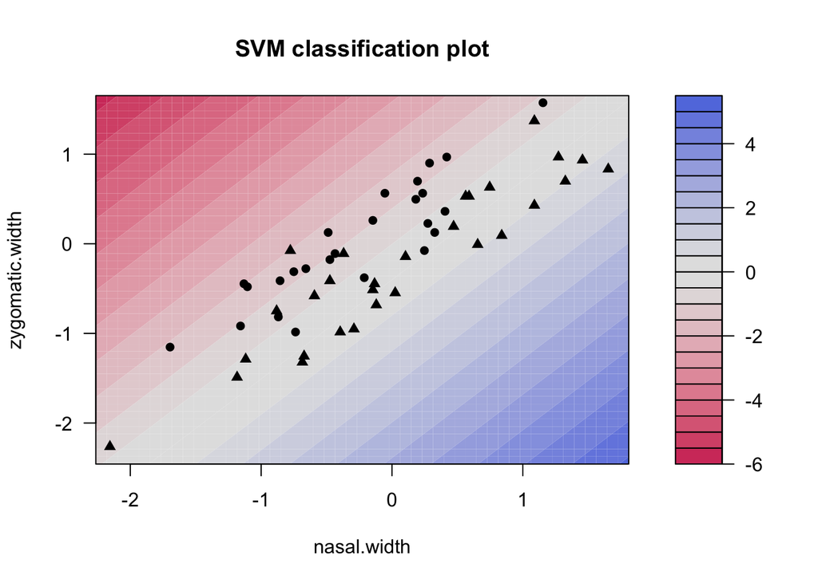

```r
#Visualization of the Linear split
kernlab::plot(svm_linear$finalModel)
```

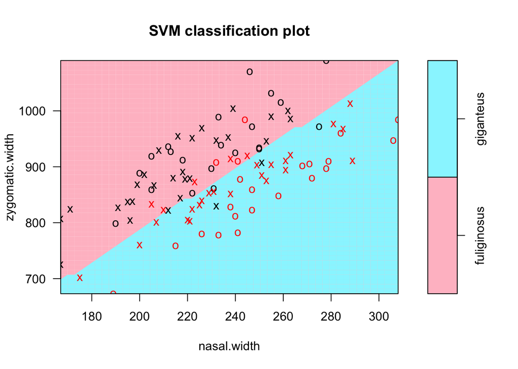

```r
plot_data <- kangaroo_selected %>%
  select(species, zygomatic.width, nasal.width)

e1071_linear_model <- svm(
  species ~ .,
  data = plot_data,
  method = "C-classification",
  kernel = "linear",
  cost = 0.16121213)

plot(e1071_linear_model, plot_data, zygomatic.width ~ nasal.width, col = c("pink", "cadetblue1"))
```

As anticipated, a linear kernel sufficed for the 2-predictor SVM model. We first tried out a Linear Kernel SVM by using the `caret` package’s `svmLinear` method. The CV Accuracy plot shows that the model reached the highest accuracy at values of C that are very close to 0, which matches our prediction that only a small $𝐶$ is needed. We used 10-fold cross validation to identify this optimal mode, which has an accuracy of 0.889 at $𝐶$ = 0.16121213. Using `caret` and `kernlab`, we were able to generate a contourplot of the split. However, as the boundaries were not clear in this plot, we used the CV results as input for another package `e1071` with a kernel function to further refine our model. In the plot, the support vectors are marked as $X$, and black mark stands for `fuliginosus` and red mark stands for `giganteus`. In this final model with $𝐶$ = 0.16121213 and a linear kernal function, almost all observations are correctly classified.

## Part 3: Full analysis

Because we have all predictors to classify the species, we can’t use a single graph to see the relationship before we train our model. The algorithm below uses all the predictors in the datset to create the hyperplane to classify the species. We tried linear split, polynomial split, and radial split (radial base function, or RBF) to see which method gives us the highest accuracy. We started with a large sequence of C and used the cross validation to identify the optimal tuning value. The algorithm normalizes all the data before the training process (`preProcess`) to standardize variables of different scales and ensure that no predictors exert unduly large influence over the algorithm merely because of its unit and scale. Our tuning parameters are C which is the cost of the errors, and we tune the different values of C to find the highest accuracy.

### Building the all-predictor model

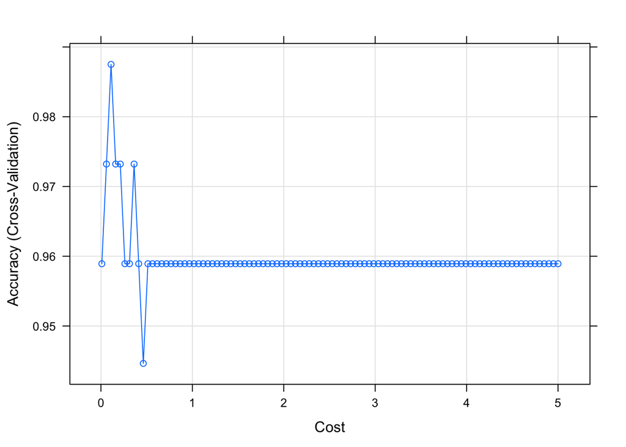

```r
#Set the seed
set.seed(253)

#SVM Linear model
svm_linear_all <- train(
  species ~ .,
  data = kangaroo_selected,
  method = "svmLinear",
  trControl=trainControl(method = "cv", number = 10, selectionFunction = "best"),
  preProcess = c("center", "scale"),
  metric = "Accuracy",
  tuneGrid = data.frame(C = c),
  na.action = na.omit
  )

#Plot the accuracies
plot(svm_linear_all)
```

Similar to Part 2, we used the results of `caret` SVM training to refine our `svm_linear_all` model with a linear kernel and $𝐶$ = 0.1108081. We also built models with a polynomial and a radial kernel but found that these resulted in complex models that did not significancly improve accuracy. Thus, our final model is the linear SVM with a linear kernel and tuning parameter $𝐶$ =0.1108081.

```r
#Model with linear kernel
e1071_linear_all_model <- svm(
  species ~ .,
  data = kangaroo_selected,
  method = "C-classification",
  kernel = "linear",
  cost = 0.1108081)
```

The mechanism for all predictors is similar to the previous analysis when we have 2 predictors. We run the algorithm for the optimal C and we need to use the e1017 package to get more information of the hyperplane which the svm algorithm can’t provide us. Therefore, we need to run the e1071 algorithm for the coeffcients and relative significance of the variables.

### Optimal model

```r
svm_linear_all$results %>%
  filter(C == svm_linear_all$bestTune$C)
```

```
##           C Accuracy Kappa AccuracySD    KappaSD
## 1 0.1108081   0.9875 0.975 0.03952847 0.07905694
```

The CV accuracy of the linear model is 98.75% with the cost of 0.1108081, the CV accuracy of the polynomial model is 95.7% with the cost of 0.2620202, and the CV accuracy of the radial model is 75.89% with the cost of 1.018081. We would choose the linear model which gives us the highest accuracy, and we should expect that our classification of species on the new data would be 98.75% correct.

**Visualiztion of Full SVM classification** :Since we use all the predictors in this model, the dimension of the graph is too high for us to visualize the hyperplane. Therefore, we can’t visualize the SVM hyperplane or the margins because of the high dimension.

## Part 4: Summary

The final model using all predictors in the dataset is a linear SVM model with $𝐶$ = 0.1108081 and a linear kernel. It can accurately predict 98.75% of new datasets, which is a great result from cross validation.

```r
#Create a dataset with categorical variable `sex` mutated to 2 numeric variables for `varImp` function
kangaroo_selected_1 <- kangaroo_selected%>%
  mutate(Female = if_else(sex == "Female",1,0),Male = if_else(sex == "Male",1,0))%>%
  select(-sex)

svm_linear_all_1 <- train(
  species ~ .,
  data = kangaroo_selected_1,
  method = "svmLinear",
  trControl= trainControl(method = "cv", number = 10, selectionFunction = "best"),
  preProcess = c("center", "scale"),
  metric = "Accuracy",
  tuneGrid = data.frame(C = c),
  na.action = na.omit
  )
```

```r
varImp(svm_linear_all_1)
```

```
## ROC curve variable importance
##
##                      Importance
## nasal.length            100.000
## mandible.width           95.933
## crest.width              91.068
## nasal.width              77.269
## ramus.height             59.622
## zygomatic.width          59.405
## foramina.length          59.259
## mandible.depth           46.187
## occipitonasal.length     42.193
## palate.width             35.875
## squamosal.depth          34.060
## mandible.length          20.189
## occipital.depth          15.323
## .rostral.width           13.871
## orbital.width            11.983
## basilar.length            5.011
## palate.length             2.614
## lacrymal.width            2.033
## Male                      0.000
## Female                    0.000
```

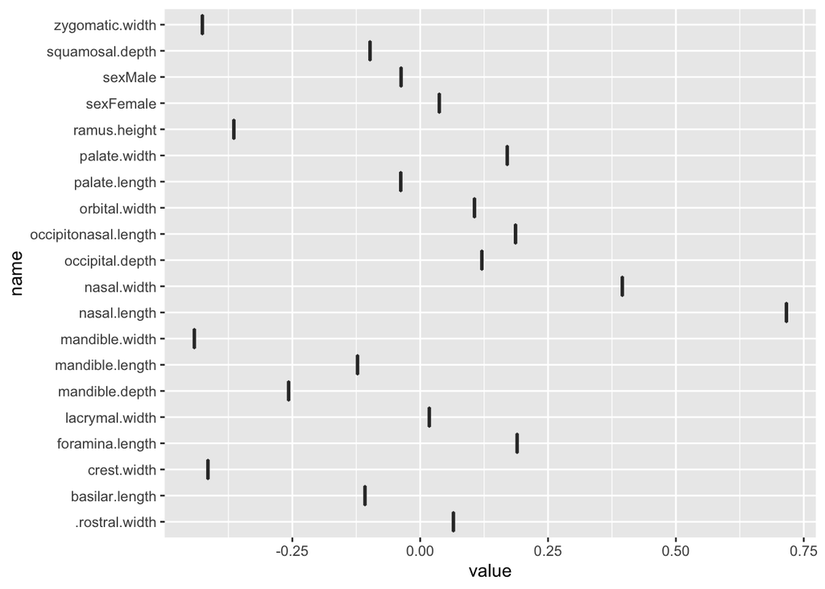

```r
#visualization of coefs
w <- t(e1071_linear_all_model$coefs) %*% e1071_linear_all_model$SV
w1<- t(w)
w1 <- data.frame(w1)
w1 <- tibble::rownames_to_column(w1, "name")
w1 <- w1 %>%
  mutate(value = w1)%>%
  select(-w1)

ggplot(data = w1, aes(x = name, y= value))+
  geom_boxplot()+
  coord_flip()
```

The graph above shows the coefficients of all predictors of the hyperplane. The absolute magnitude of the coefficient represents its significance level so that a predictor would be more important if its coefficient is more away from zero in the graph.

Using the powerful classification algorithm SVM, we built highly accurate models for identifying 2 species of kangaroo in Australia. This is a linear SVM model with low $C$ value and a linear kernal term. The results of this analysis also advanced our understanding of the relationship between species and anatomical predictors collected for the kangaroo dataset. We established that, at least in distinguishing between 2 species `fuliginosus` and `giganteus`, `nasal.length`, `mandable.width`, `crest.width` and `nasal.width` are particularly important while `lacrymal.width`, `palate.length`, and `basilar.length` are the least important and can be removed for simpler models. An application of this conclusion is a focus on collecting data for the most important variables helpful for species identification.

## Part 5: Contributions

All four members studied SVM as a machine learning algorithm together. Jack and Debbie started the project, researched implementations of SVM on R and wrote the codes for building SVM models. Alex and Phuong finished the analysis and editting for this write-up.

## Appendix

### 2-predictor analysis

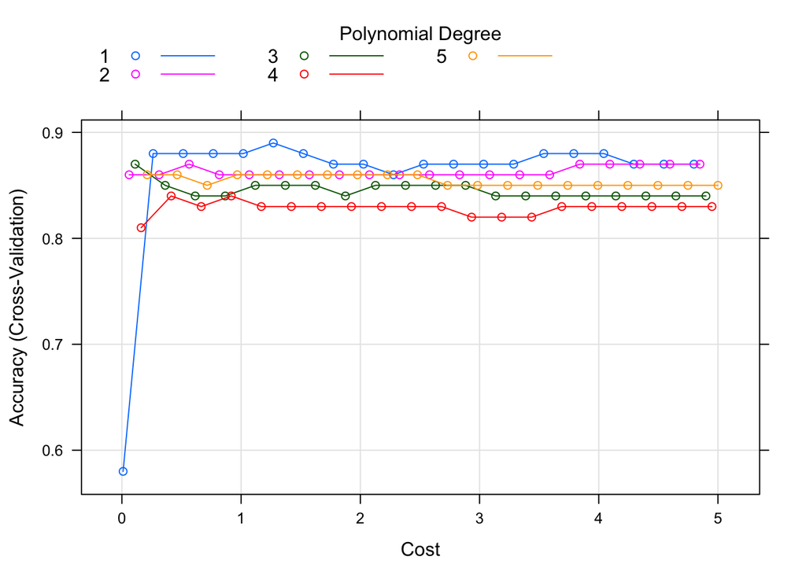

```r
#svm polynomial model
svm_poly <- train(
  species ~ zygomatic.width + nasal.width,
  data = kangaroo_selected,
  method = "svmPoly",
  trControl=trainControl(method = "cv", number = 10, selectionFunction = "best"),
  preProcess = c("center", "scale"),
  metric = "Accuracy",
  tuneGrid = data.frame(C = c, scale = TRUE, degree = seq(1, 5, length = 5)),
  na.action = na.omit
  )

#Accuracy plot
plot(svm_poly)
```

```r
#Best tune
svm_poly$results %>%
  filter(C == svm_poly$bestTune$C)
```

```
##          C scale degree Accuracy Kappa AccuracySD  KappaSD
## 1 1.270101  TRUE      1     0.89  0.78  0.1100505 0.220101
```

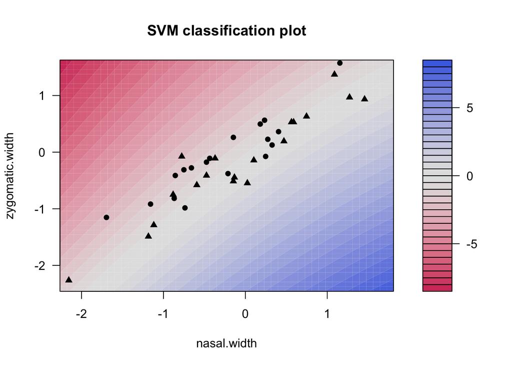

```r
svm_poly_1 <- train(
  species ~ zygomatic.width + nasal.width,
  data = kangaroo_selected,
  method = "svmPoly",
  trControl=trainControl(method = "cv", number = 10, selectionFunction = "best"),
  preProcess = c("center", "scale"),
  metric = "Accuracy",
  tuneGrid = data.frame(C = c, scale = TRUE, degree = 2),
  na.action = na.omit
  )

kernlab::plot(svm_poly_1$finalModel)
```

```r
svm_poly_1$results %>%
  filter(C == svm_poly$bestTune$C)
```

```
##          C scale degree  Accuracy Kappa AccuracySD   KappaSD
## 1 1.270101  TRUE      2 0.8477778 0.695  0.1191016 0.2385721
```

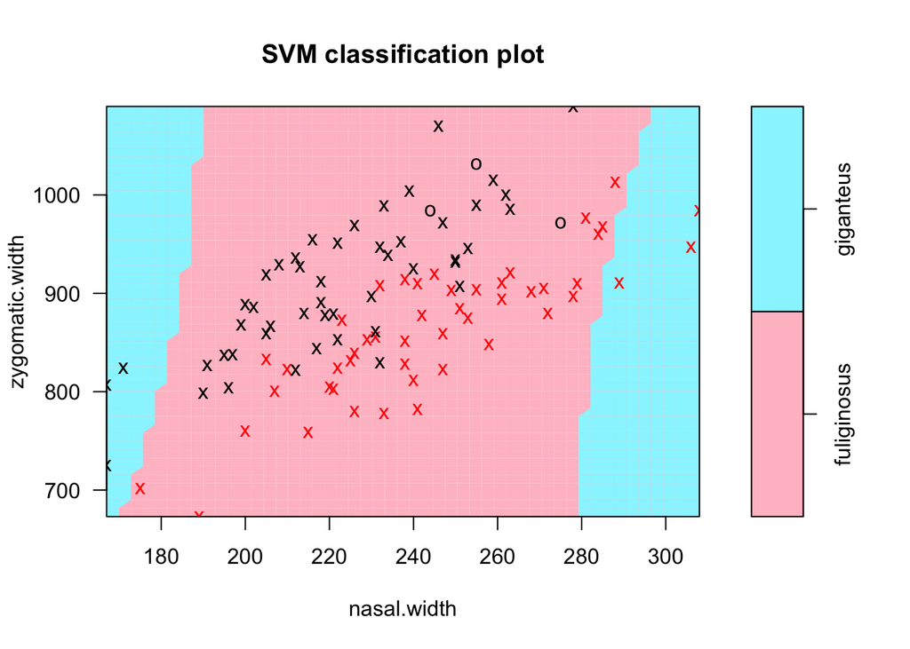

```r
e1071_quadratic_model <- svm(
  species ~ .,
  data = plot_data,
  method = "C-classification",
  kernel = "polynomial",
  degree = 2,
  cost = 0.7630151)

plot(e1071_quadratic_model, plot_data, zygomatic.width ~ nasal.width, col = c("pink", "cadetblue1"))
```

```r
#svm RBF model
svm_rbf <- train(
  species ~ zygomatic.width + nasal.width,
  data = kangaroo_selected,
  method = "svmRadial",
  trControl=trainControl(method = "cv", number = 10, selectionFunction = "best"),
  preProcess = c("center", "scale"),
  metric = "Accuracy",
  tuneGrid = data.frame(C = c, sigma = sig),
  na.action = na.omit
)

svm_rbf$results %>%
  filter(C == svm_rbf$bestTune$C)
```

```
##          C    sigma  Accuracy Kappa AccuracySD  KappaSD
## 1 1.118889 1.118889 0.8677778 0.735  0.1077835 0.216089
```

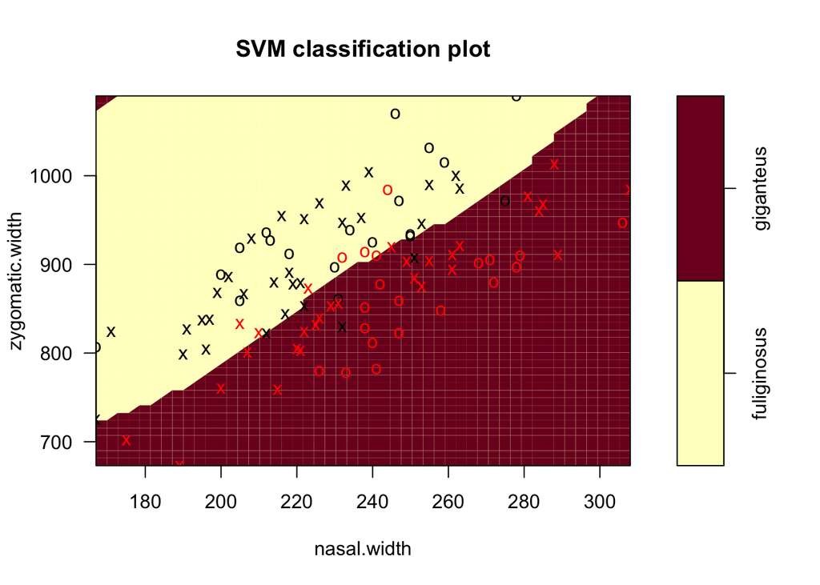

```r
e1071_rbf_model <- svm(
  species ~ zygomatic.width + nasal.width,
  data = plot_data,
  method = "C-classification",
  kernel = "radial",
  gamma = 0.461809,
  cost = 0.461809)

plot(e1071_rbf_model, plot_data, zygomatic.width ~ nasal.width)
```

Though we have convinced ourselves that a Linear split would be the best in this situation, we still attempted multiple degrees of polynomial kernel split, with degrees ranging from 1~5. Not suprisingly, when degree = 1, we had the same highest accuracy of 0.889, but with different $𝐶$, this is because the `svmPoly` method has another tuning parameter scale, which rescales the dataset thus giving a different yet still small $𝐶$. We also used the same technique we used above to plot the quadratic split(we are not going to plot all 5 degrees, since some degrees do not have good accuracys thus the plot should be kind of a mess). In the plot, the support vectors are marked as $X$, and black mark stands for `fuliginosus` and red mark stands for `giganteus`.

### All-predictor analysis

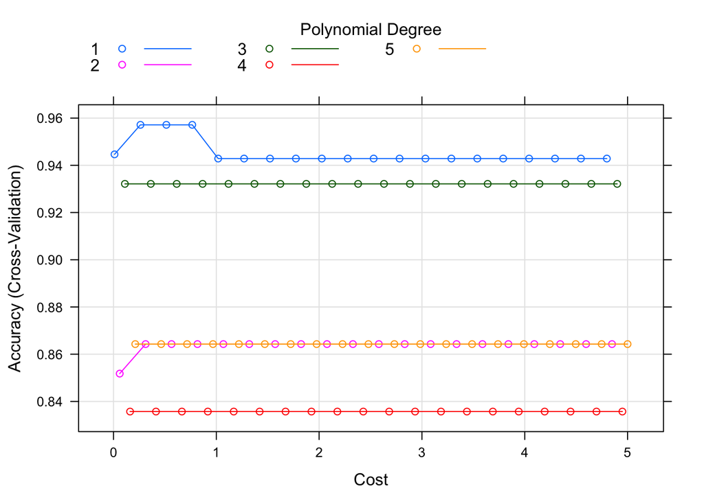

```r
#SVM Polynomial model
svm_poly_all <- train(
  species ~ .,
  data = kangaroo_selected,
  method = "svmPoly",
  trControl=trainControl(method = "cv", number = 10, selectionFunction = "best"),
  preProcess = c("center", "scale"),
  metric = "Accuracy",
  tuneGrid = data.frame(C = c, scale = TRUE, degree = seq(1, 5, length = 5)),
  na.action = na.omit
  )

e1071_poly_all_model <- svm(
  species ~ .,
  data = kangaroo_selected,
  method = "C-classification",
  kernel = "polynomial",
  cost = 0.2620202)

plot(svm_poly_all)
```

```r
svm_poly_all$results %>%
  filter(C == svm_poly_all$bestTune$C)
```

```
##           C scale degree  Accuracy     Kappa AccuracySD   KappaSD
## 1 0.2620202  TRUE      1 0.9571429 0.9135652 0.06900656 0.1393309
```

[figure not shown]

```r
#SVM RBF model
svm_rbf_all <- train(
  species ~.,
  data = kangaroo_selected,
  method = "svmRadial",
  trControl=trainControl(method = "cv", number = 10, selectionFunction = "best"),
  preProcess = c("center", "scale"),
  metric = "Accuracy",
  tuneGrid = data.frame(C = c, sigma = sig),
  na.action = na.omit
)

e1071_radial_all_model <- svm(
  species ~ .,
  data = kangaroo_selected,
  method = "C-classification",
  kernel = "radial",
  cost = 1.018081)

plot(svm_rbf_all)
```

```r
svm_rbf_all$results %>%
  filter(C == svm_rbf_all$bestTune$C)
```

```
##          C    sigma  Accuracy     Kappa AccuracySD  KappaSD
## 1 1.018081 1.018081 0.7589286 0.5258936  0.1626319 0.317019
```